# project_1

### Damped & Adjusted Holt-Winters Model

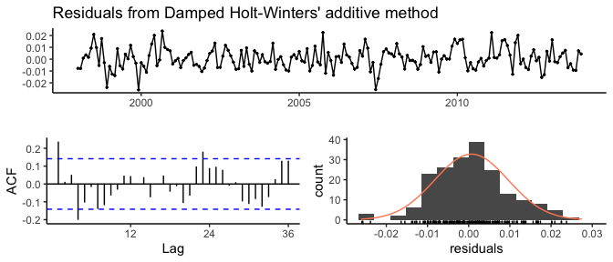

```
#>
#>  Ljung-Box test
#>
#> data:  Residuals from Damped Holt-Winters' additive method
#> Q* = 47.391, df = 7, p-value = 4.682e-08
#>
#> Model df: 17.   Total lags used: 24
```

The preformance of this model is about the same as above.

### ARIMA Model

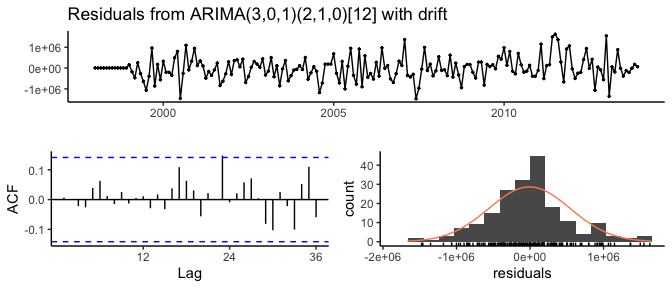

```
#>
#>  Ljung-Box test
#>
#> data:  Residuals from ARIMA(3,0,1)(2,1,0)[12] with drift
#> Q* = 11.549, df = 17, p-value = 0.8266
#>
#> Model df: 7.   Total lags used: 24
```

This model seems to be the best. There is only one ACF spike outside of the threshold and it only by a small amount. My working theory is this is the model I should use, but I will check this using cross validation.

## Cross Validation

In order to understand how well a model is likely to preform at predicting out of sample data, I will use the `tsCV` function and evaluate the models. My goal is to minimize the RMSE. First I will get the errors from the cross validation process, then I will compute the RMSE.

| Model | RMSE |
| --- | --- |
| ARIMA | 659529.8 |
| Holt-Winters | 1010721.9 |
| Adjusted Holt-Winters | 1373617.3 |
| Damped & Adjusted Holt-Winters | 1547751.3 |

The ARIMA model had the best cross validation results.

## Model Selection

Given that the ARIMA model minimized the RMSE in the cross validation, I will use it to forecast residential power consumption.

## Summary

I set out to forecast residential power consumption. Four modeling techniques were tested for accuracy using cross-validation. In the end an ARIMA model was selected bercause it minimized the RMSE. Here’s my forcast for the next 12 months of power usage:

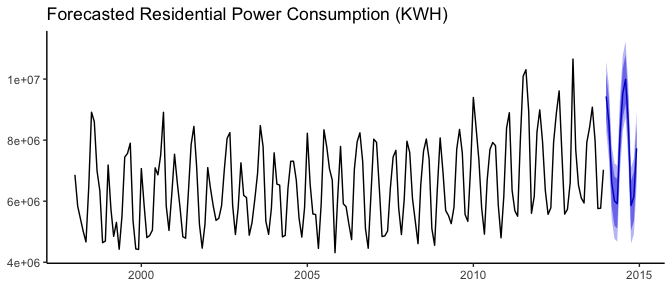

|  | Point Forecast | Lo 80 | Hi 80 | Lo 95 | Hi 95 |
| --- | --- | --- | --- | --- | --- |
| Jan 2014 | 9433336 | 8688058 | 10178615 | 8293531 | 10573141 |
| Feb 2014 | 8570219 | 7785677 | 9354761 | 7370366 | 9770072 |
| Mar 2014 | 6615312 | 5830157 | 7400467 | 5414521 | 7816102 |
| Apr 2014 | 6005538 | 5196071 | 6815004 | 4767565 | 7243510 |
| May 2014 | 5917569 | 5108101 | 6727036 | 4679595 | 7155543 |
| Jun 2014 | 8187387 | 7377114 | 8997660 | 6948182 | 9426592 |
| Jul 2014 | 9528779 | 8717809 | 10339750 | 8288507 | 10769052 |
| Aug 2014 | 9991953 | 9180963 | 10802943 | 8751650 | 11232255 |
| Sep 2014 | 8546843 | 7735715 | 9357971 | 7306330 | 9787356 |
| Oct 2014 | 5856327 | 5045196 | 6667458 | 4615809 | 7096845 |
| Nov 2014 | 6153245 | 5342114 | 6964376 | 4912727 | 7393763 |
| Dec 2014 | 7732110 | 6920971 | 8543250 | 6491580 | 8972641 |

## Part C – BONUS, optional (part or all), Waterflow_Pipe1.xlsx and Waterflow_Pipe2.xlsx

Part C consists of two data sets. These are simple 2 columns sets, however they have different time stamps. Your optional assignment is to time-base sequence the data and aggregate based on hour (example of what this looks like, follows). Note for multiple recordings within an hour, take the mean. Then to determine if the data is stationary and can it be forecast. If so, provide a week forward forecast and present results via Rpubs and .rmd and the forecast in an Excel readable file.

## Introduction

For this project I have data on water flows from two pipes. The data are captured with timestamps. I am to forecast a week forward. In the instructions for this project I am given the following hint: For multiple recordings within an hour, take the mean. I will be on the lookout for data under the hour.

## Data Exploration

I will begin by plotting the datasets:

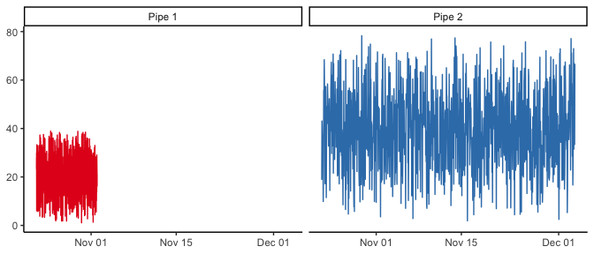

The two pipes are quite different in terms of the data they offer. Pipe 1 has a median waterflow of about 20, while pipe 2 has a median of 40. Pipe 1 also has what looks like over a week of data, while pipe 2 has over a month. Both datasets have 1000 observations. This suggests that pipe one has more fine grain observations (i.e. multiple observations in a hour or minute) while pipe 2’s data captures a longer period of time. That would explain the difference in median and the length of time covered by the respective data sets. This also is hinted at in the instructions.

### Closer Look at Pipe 1

I will look at the head and tail of pipe 1’s data to get a sense of what’s included:

| Date Time | WaterFlow |
| --- | --- |
| 2015-10-23 00:24:06 | 23.369599 |
| 2015-10-23 00:40:02 | 28.002881 |
| 2015-10-23 00:53:51 | 23.065895 |
| 2015-10-23 00:55:40 | 29.972809 |
| 2015-10-23 01:19:17 | 5.997953 |
| 2015-10-23 01:23:58 | 15.935223 |

### Closer Look at Pipe 2

I will also take a look at pipe 2’s data to see if there is anything I need to be aware of:

| Date Time | WaterFlow |
| --- | --- |
| 2015-10-23 01:00:00 | 18.81079 |
| 2015-10-23 01:59:59 | 43.08703 |
| 2015-10-23 03:00:00 | 37.98770 |
| 2015-10-23 04:00:00 | 36.12038 |
| 2015-10-23 04:59:59 | 31.85126 |
| 2015-10-23 06:00:00 | 28.23809 |

Some of the timestamps are just a bit off from the hour mark. I will need to clean that up.

## Data Cleanup

### Pipe 1

After doing this I have 236 observations.

#### Sidebar: Is there any pattern in the usage by hour?

I want to pause right here to see if there is any pattern in the the water flow by hour.

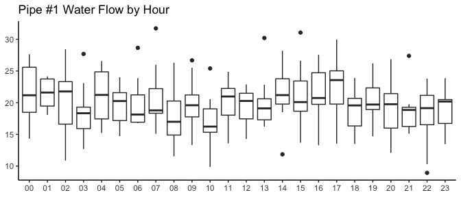

There is not a discernable pattern in the water flow by hour. With that exploration done I will convert the data to a time series object and plot it:

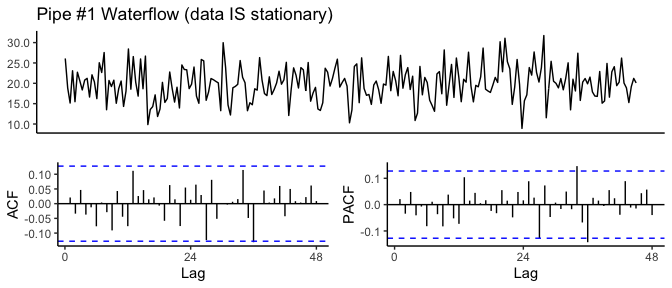

### Pipe 2

I will clean up pipe 2’s `Date Time` field by rounding it to the nearest hour.

#### Sidebar: Is there any pattern in the usage by hour?

I again want to see if there is a pattern in this pipe’s usage by hour:

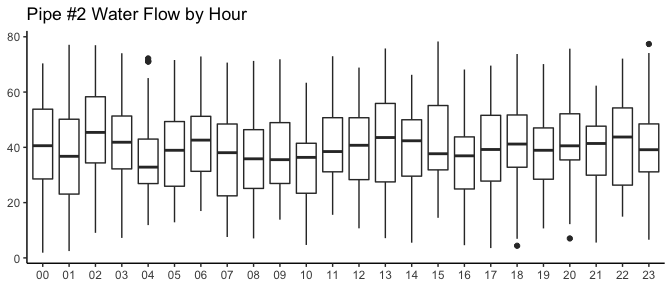

Again there is not a discernable pattern in the water flow by hour. Now I will convert the data to a time series object and plot it:

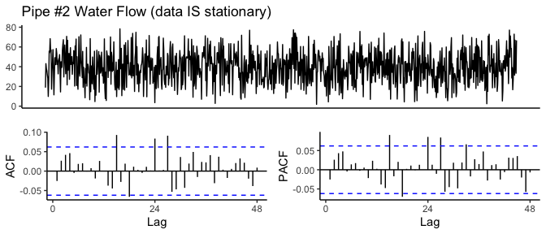

The data is stationary so we can begin forecasting.

## Model Creation

### A Note on Process

I will develop a variety of models using different methods and will validate their performance using cross validation. The model that minimizes the error will be the model of choice.

### Pipe 1 Candidates

#### STL + ETS

I will begin with a STL decomposition based model.

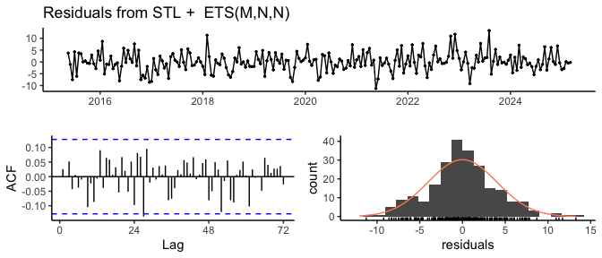

```
#>
#>  Ljung-Box test
#>
#> data:  Residuals from STL +  ETS(M,N,N)
#> Q* = 37.291, df = 45, p-value = 0.7861
#>
#> Model df: 2.   Total lags used: 47
```

This model appears to have preformed fairly well. The residuals are normal and there’s only one minor ACF spike. I’ll see how this preforms in the cross validation stage.

#### STL + ARIMA

Next I will create an ARIMA model on the STL decomposed time series.

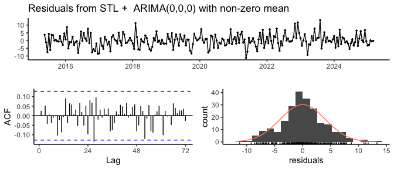

```
#>
#>  Ljung-Box test
#>
#> data:  Residuals from STL +  ARIMA(0,0,0) with non-zero mean
#> Q* = 37.292, df = 46, p-value = 0.8164
#>
#> Model df: 1.   Total lags used: 47
```

That’s strange. It is a ARIMA(0,0,0) model. That is a white-noise model. Let’s see if this is an artifact of the STL decomposition or if we get a similar result training the ARIMA model.

#### ARIMA

Last of all I will try an ARIMA model using the `auto.arima` function to define the (p,d,q) parameters.

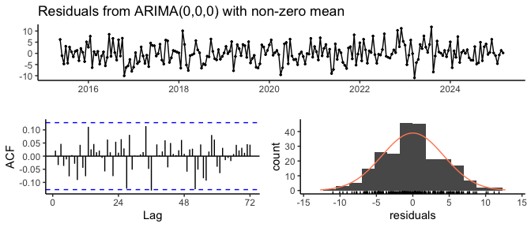

```
#>
#>  Ljung-Box test
#>
#> data:  Residuals from ARIMA(0,0,0) with non-zero mean
#> Q* = 37.178, df = 46, p-value = 0.82
#>
#> Model df: 1.   Total lags used: 47
```

Again the best model was an ARIMA(0,0,0) model! This suggests there is no reliable way to forecast the waterflow.

### Pipe 2 Candidates

#### STL + ARIMA

I will first check with a STL decomposition and ARIMA to see if it results in a white noise model.

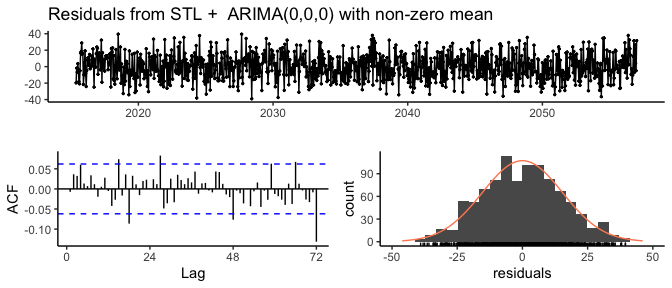

```
#>
#>  Ljung-Box test
#>
#> data:  Residuals from STL +  ARIMA(0,0,0) with non-zero mean
#> Q* = 58.308, df = 47, p-value = 0.1247
#>
#> Model df: 1.   Total lags used: 48
```

It did. Let’s see what kind of model `auto.arima` comes up with.

#### ARIMA

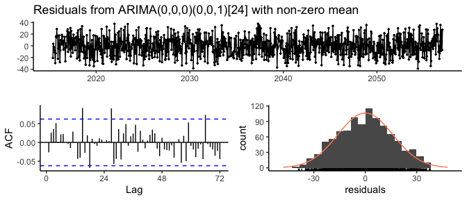

```
#>
#>  Ljung-Box test
#>
#> data:  Residuals from ARIMA(0,0,0)(0,0,1)[24] with non-zero mean
#> Q* = 55.158, df = 46, p-value = 0.1669
#>
#> Model df: 2.   Total lags used: 48
```